# web_scraping_tdf

Sille Hasselbalch Markussen

11/6/2022

```r
library(rvest)
library(dplyr)
library(tidyr)
library(stringr)
library(janitor)
library(ggplot2)
```

I will be using the archive on https://www.cyclingstage.com/ to scrape data about Tour de france stages from 2015 to 2023. I’ll use this data to see the change in stage type (e.g. flat, hill mountain, etc.) over the years.

### Scraping data

**Defining scrape funciton and testing it**

```r
scrape_tdf <- function(website){
    url <- read_html(website)
    tdf_table <- url %>%
            html_nodes("table") %>%
            html_table()  # result is a list
  tdf_table <- do.call(cbind,unlist(tdf_table, recursive = FALSE))
}

# Testing on 2015 route
tdf2015 <- scrape_tdf("https://www.cyclingstage.com/tour-de-france-2015-route/")
summary(as_tibble(tdf2015))
```

```
##       V1                Date           Start and finish      Length
##  Length:23          Length:23          Length:23          Length:23
##  Class :character   Class :character   Class :character   Class :character
##  Mode  :character   Mode  :character   Mode  :character   Mode  :character
##      Type
##  Length:23
##  Class :character
##  Mode  :character
```

```r
# It works :))
```

**Scraping routes from 2015-2023**

```r
# Create a container for the results
tdf_route_stages <- 0  # we need to create an empty container

# Create a list of url endings for the different years
year_endings <- paste0(2015:2023,"-route/")

# Loop over the years to iterate the scraping
for (year in year_endings){
    print(year) # let's check which year we are in
    url <- "https://www.cyclingstage.com/tour-de-france-"
    website <- paste0(url,year)  # here we bind the year to the website to form the URL
    tdf_table <- scrape_tdf(website) # here we apply the scraping function
    tdf_route_stages <- rbind(tdf_route_stages, tdf_table) # we add the scraped results from the given year to our master dataset
    }
```

```
## [1] "2015-route/"
## [1] "2016-route/"
## [1] "2017-route/"
## [1] "2018-route/"
## [1] "2019-route/"
## [1] "2020-route/"
## [1] "2021-route/"
## [1] "2022-route/"
## [1] "2023-route/"
```

```r
head(tdf_route_stages)
```

```
##                      Date
## tdf_route_stages "0" "0"
##                  "1" "Sa 4-7"
##                  "2" "Su 5-7"
##                  "3" "Mo 6-7"
##                  "4" "Tu 7-7"
##                  "5" "We 8-7"
##                  Start and finish
## tdf_route_stages "0"
##                  "Tour de France 2015 Stage 1 Utrecht (NL) – Utrecht"
##                  "Tour de France 2015 Stage 2 Utrecht – Neeltje Jans (NL)"
##                  "Tour de France 2015 Stage 3 Antwerp (B) – Mur de Huy (B)"
##                  "Tour de France 2015 Stage 4 Seraing (B) – Cambrai"
##                  "Tour de France 2015 Stage 5 Arras – Amiens"
##                  Length     Type
## tdf_route_stages "0"        "0"
##                  "13,7 km"  "ITT"
##                  "166 km"   "flat"
##                  "159.5 km" "hilly"
##                  "223.5 km" "cobbles"
##                  "189.5 km" "flat"
```

### Cleaning the data

**Changing data format to tibble**

```r
tdf_route_stages <- as_tibble(tdf_route_stages)
summary(tdf_route_stages)
```

```
##       V1                Date           Start and finish      Length
##  Length:209         Length:209         Length:209         Length:209
##  Class :character   Class :character   Class :character   Class :character
##  Mode  :character   Mode  :character   Mode  :character   Mode  :character
##      Type
##  Length:209
##  Class :character
##  Mode  :character
```

**Handling empty values**

```r
# Removing first row (it is empty)
tdf_route_stages <- tdf_route_stages[-1,]

# Removing rest days
tdf_route_stages <- tdf_route_stages %>%
    filter(!grepl("[Rr]est day*", Length))
```

**Cleaning length column**

```r
# Making decimal point consistent
tdf_route_stages$Length <- gsub("\\,", "\\.", tdf_route_stages$Length)

# Extracting only numbers from the string and changing the column to numeric
tdf_route_stages$Length <- as.numeric(regmatches(tdf_route_stages$Length, regexpr("\\d+\\.?\\d+",tdf_route_stages$Length)))
```

**Cleaning dates**

```r
tdf_route_stages$Year <- as.numeric(substring(tdf_route_stages$`Start and finish`, 15, 19))
# NAs are produced since not all start and finish have the year in the string
# Examining the data, this inconsistency is only for 2023 stages.
# I therefore replace NAs with 2023
tdf_route_stages$Year <- replace_na(tdf_route_stages$Year, 2023)

# Removing any text other than the date format d-m
tdf_route_stages$Date <- regmatches(tdf_route_stages$Date, regexpr("\\d+\\-\\d",tdf_route_stages$Date))
# Adding year to the date
tdf_route_stages$Date <- paste0(tdf_route_stages$Date, "-", tdf_route_stages$Year)

# This last part may be a bit unnessecary, but I thought at some point that I might have to use it :)
```

**Stage numbers**

```r
tdf_route_stages<- tdf_route_stages %>%
    rename(Stage_number = V1)
tdf_route_stages$Stage_number <- as.numeric(tdf_route_stages$Stage_number)
```

**Grouping varieties of stage types**

```r
# Checking the unique stage types
unique(tdf_route_stages$Type)
```

```
##  [1] "ITT"                    "flat"                   "hilly"
##  [4] "cobbles"                "TTT"                    "hilly, finish uphill"
##  [7] "mountains"              "hilly, flat finish"     "flat, finish uphill"
## [10] "hills, flat finish"     "mountains, flat start"  "mountains, flat finish"
## [13] "ITT, mountains"         "flat ITT"               "finish uphill"
## [16] "mountain finish"        "heuvels"                "hills"
## [19] "hilly, flat start"      "ITT (hills)"            "mountain"
```

I find the following categories:  
**ITT** (individual time trial) - also including flat ITT, ITT (mountains), and ITT (hills)  
**cobbles**  
**mountains** - also including mountain, mountain finish, mountains (flat start), and mountains (flat finish)  
**hills** - also including hills (flat finish), hilly (flat start), hilly (flat finish), heuvels, hilly, hilly (finish uphill), and finish uphill  
**flat** - also including flat, finish uphill  
**TTT** (team time trial)

```r
# new column for grouped types
tdf_route_stages$Type_grouped <- as.factor(tdf_route_stages$Type)

# Defining the levels of types
levels(tdf_route_stages$Type_grouped) <-
    list("ITT (Individual time trial)"= c("ITT", "flat ITT","ITT, mountains", "ITT (hills)"),
             "cobbles" = "cobbles",
             "mountains" = c("mountain", "mountain finish","mountains, flat start", "mountains, flat finish"),
             "hills" = c("hills, flat finish", "hilly, flat start","hilly, flat finish", "heuvels", "hilly","hilly, finish uphill", "finish uphill"),
             "flat" = c("flat", "flat, finish uphill"),
             "TTT (Team time trial)" = "TTT")
```

The data is now properly cleaned and wrangled to see the change in stage type (e.g. flat, hill, mountain, etc.) over the years.

### Plotting the data

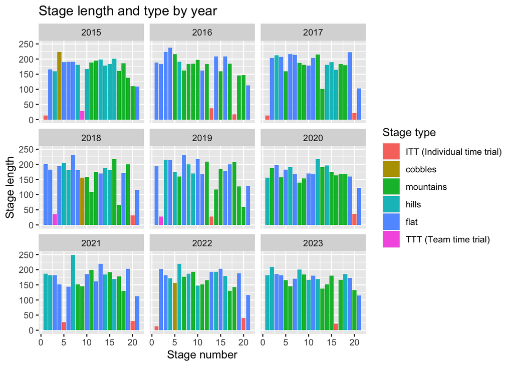

```r
ggplot(tdf_route_stages, aes(y = Length, x= Stage_number, fill = Type_grouped)) +
  geom_col()+
    labs(x = "Stage number", y = "Stage length", fill = "Stage type", title = "Stage length and type by year")+
    facet_wrap(~Year)
```

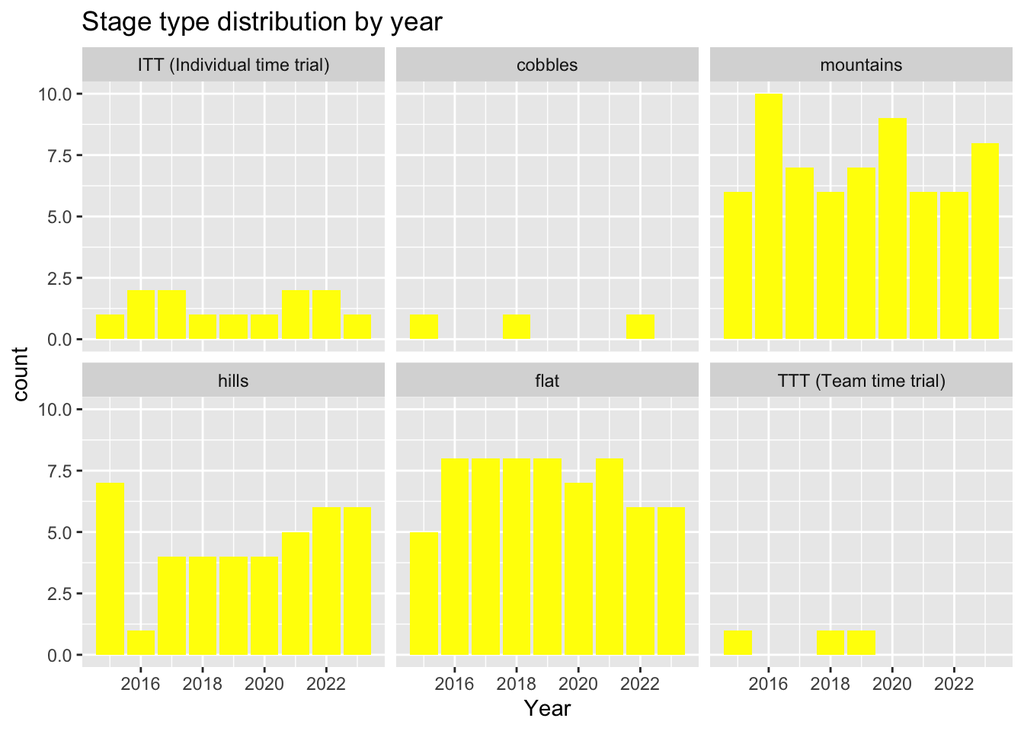

```r
ggplot(tdf_route_stages, aes(x= Year)) +
  geom_bar(fill = "Yellow")+
    labs(title = "Stage type distribution by year") +
    facet_wrap(~Type_grouped)
```

It seems that the types of stages in the Tour de France routes do not differ much over the years. One can see that team time trials are less prevalent in the more recent year. It is also visible that the route in 2016 included more mountain stages and less stages with hills than the other years.